# Assignment 14: Reddit - Text Mining

[figure not shown]

*How to do it?*:

- Open the Rmarkdown file of this assignment (link) in Rstudio.
- Right under each **question**, insert a code chunk (you can use the hotkey `Ctrl + Alt + I` to add a code chunk) and code the solution for the question.
- `Knit` the rmarkdown file (hotkey: `Ctrl + Alt + K`) to export an html.
- Publish the html file to your Githiub Page.

*Submission*: Submit the link on Github of the assignment to Canvas

In this Assignment we will analyze text data scrapped from [Reddit](https://www.reddit.com/), an American social news aggregation, content rating, and discussion website. We will use the package `RedditExtractoR` to help use collect the data.

To learn more about about the package:

https://cran.r-project.org/web/packages/RedditExtractoR/RedditExtractoR.pdf

We use the function `find_thread_urls` to collect the threads in the subreddit `college`.

```r
library(RedditExtractoR)
library(tidytext)
library(ggpubr)
library(tidyverse)
library(knitr)
library(lubridate)

df <- find_thread_urls(sort_by="new", subreddit = 'college')
```

We can save the data for faster access later and also limit our number of times to inquire the data from Reddit.

```r
write_csv(df, "reddit_college.csv")
```

```r
library(RedditExtractoR)
library(tidytext)
library(ggpubr)
library(tidyverse)
library(knitr)
library(lubridate)
df = read_csv("reddit_college.csv")
```

## Data Wrangling

The collected dataset has two text columns `title` and `text`. We can create some categorical variables for our analysis.

The `timestamp` variable can give us the time of the day for the threads. We can convert the time to hours (numeric value from 0 to 24).

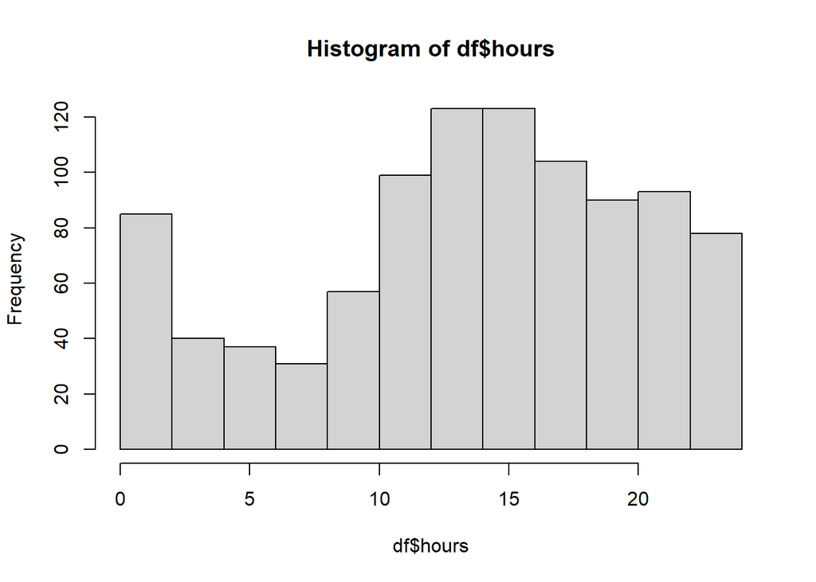

```r
df$date_time = as.POSIXct(df$timestamp, origin="1970-01-01")
df = drop_na(df)

# Create a time variable
df$time = format(as.POSIXct(df$date_time), format = "%H:%M:%S")

# change time to hours
df$hours = as.numeric(hms(df$time), "hours")
hist(df$hours)
```

We can create categorical variables for our analysis.

```r
# Create binary variable
df$day_night = case_when(((df$hours >= 7)&(df$hours<=17))~ "day",
                         TRUE ~ "night")

df$threads = case_when(df$comments > 2 ~ "Long",
                         TRUE ~ "Short")
```

## Word Cloud

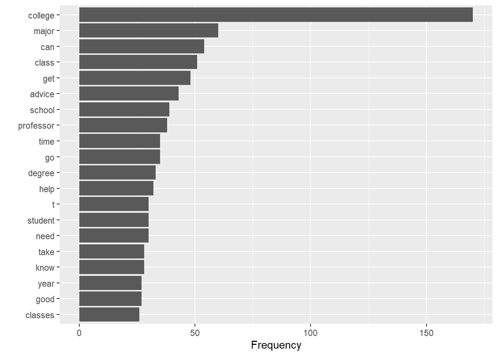

```r
df %>%
  unnest_tokens(input = title, output = word) %>%
  anti_join(get_stopwords()) %>%
  count(word, sort = TRUE) %>%
  head(20) %>%
  ggplot(aes(x = n, y = reorder(word, n))) +
  geom_col() +
  labs(y = '', x = 'Frequency')
```

We notice that there are some words that have only one letter in the frequency. We can filter out these words

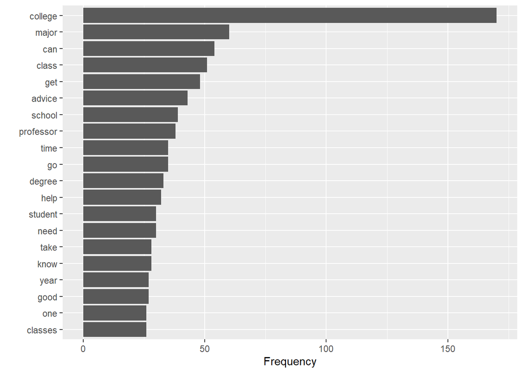

```r
df %>%
  unnest_tokens(input = title, output = word) %>%
  anti_join(get_stopwords()) %>%
  count(word, sort = TRUE) %>%
  filter(nchar(word)>1) %>%
  head(20) %>%
  ggplot(aes(x = n, y = reorder(word, n))) +
  geom_col() +
  labs(y = '', x = 'Frequency')
```

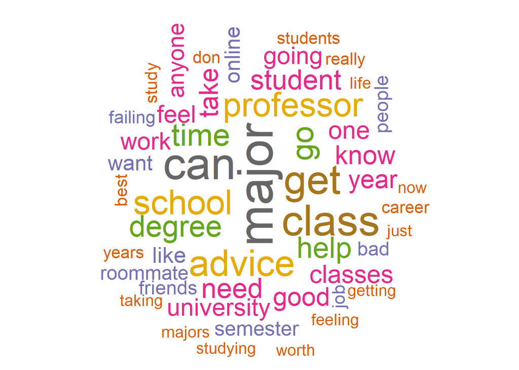

```r
library(wordcloud)
pal <- brewer.pal(8,"Dark2")

df %>%
  unnest_tokens(input = title, output = word) %>%
  anti_join(get_stopwords()) %>%
  count(word, sort = TRUE) %>%
  filter(nchar(word)>1, word!="college") %>%
  with(wordcloud(word, n, random.order = FALSE, max.words = 50, colors=pal))
```

## Sentiment Analysis

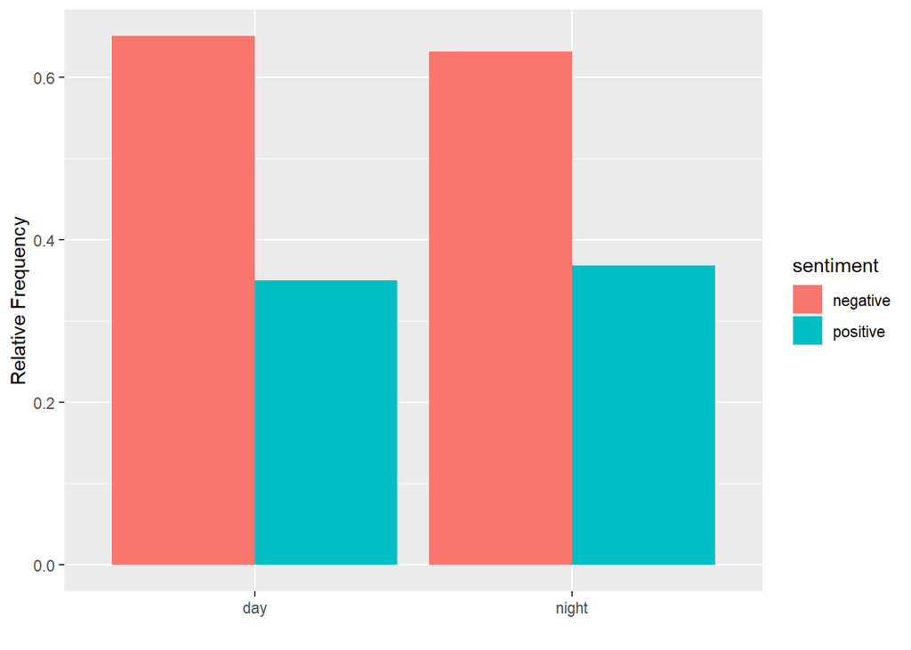

```r
df %>%
    unnest_tokens(input = title, output = word) %>%
    anti_join(get_stopwords()) %>%
    count(day_night, word, sort = TRUE) %>%
    group_by(day_night) %>%
    inner_join(get_sentiments("bing")) %>%
    filter(!is.na(sentiment)) %>%
    count(sentiment, sort = TRUE) %>%
    group_by(day_night) %>%
    mutate(n = n/sum(n)) %>%
    ggplot(aes(day_night, n, fill=sentiment))+geom_col(position = 'dodge')+
    labs(y='Relative Frequency', x ='')
```

## Modeling

Let’s train a model to predict from the title if a thread is long (more than 2 comments) or short (no more than 2 comments).

```r
# library(caret)
# library(themis)
# library(textrecipes)
# library(tidyverse)
#
# df = read_csv('reddit_college.csv')
#
# df$threads = case_when(df$comments > 2 ~ "Long",
#                          TRUE ~ "Short")
#
# # Select data and set target
# df <- df %>%
#   mutate(target = threads) %>%
#   select(target, title)
#
# # Convert text data to numeric variables
# a <- recipe(target~title,
#        data = df) %>%
#   step_tokenize(title) %>%
#   step_tokenfilter(title, max_tokens = 100) %>%
#   step_tfidf(title) %>%
#   step_normalize(all_numeric_predictors()) %>%
#   step_smote(target) %>%
#   prep()
# df <- juice(a)
#
# # Using Caret for modeling
# set.seed(12345)
# splitIndex <- createDataPartition(df$target, p = .7,
#                                   list = FALSE)
# df_train <- df[ splitIndex,]
# df_test <- df[-splitIndex,]
#
# forest_ranger <- train(target~., data=df_train,
#                         method = "ranger")
#
# pred <- predict(forest_ranger, df_test)
#
# cm <- confusionMatrix(data = pred, reference = df_test$target)
# cm$overall[1]
#
# d = data.frame(pred = pred, obs = df_test$target)
# library(yardstick)
# d %>% conf_mat(pred, obs) %>% autoplot
```

## Question

Collect data from Reddit to do text mining (word clouds, sentiment analysis and modelling) for at least two text variables.

## Collecting and Storing Data

```r
library(RedditExtractoR)
library(tidytext)
library(ggpubr)
library(tidyverse)
library(knitr)
library(lubridate)

##########################################################################################
# Had to comment out the below lines of code because it was not knitting. Figured this is not a huge deal since I was able to write the data that was extracted from Reddit into a csv, then call this csv to define the history_df
##########################################################################################

# Collecting data from the AskHistorians subreddit
#history_df <- find_thread_urls(sort_by="new", subreddit = 'AskHistorians')

# Writing collected data to a csv for easier access
#write_csv(history_df, "History_Reddit.csv")
```

```r
library(RedditExtractoR)
library(tidytext)
library(ggpubr)
library(tidyverse)
library(knitr)
library(lubridate)
# Reading in data from csv
history_df = read_csv("History_Reddit.csv")
```

## Looking at Time Variables

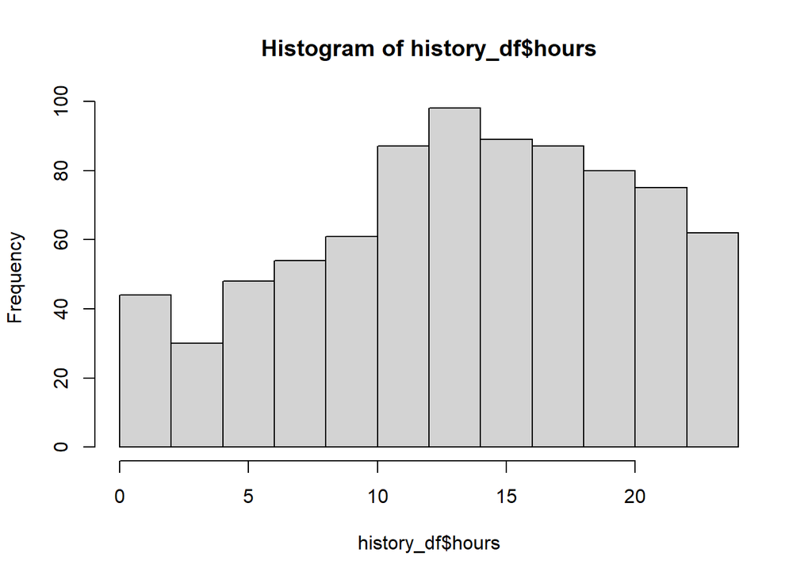

```r
# Extracting time of day from date_time variable
history_df$date_time = as.POSIXct(history_df$timestamp, origin="1970-01-01")
history_df = drop_na(history_df)

# Creating a new variable for time
history_df$time = format(as.POSIXct(history_df$date_time), format = "%H:%M:%S")

# Creating a variable to capture just the hours from the time variable
history_df$hours = as.numeric(hms(history_df$time), "hours")

# Plotting the hours variable to see post frequency at each hour
hist(history_df$hours)
```

```r
# Creating a variable to see the range of dates during which the extracted posts were created
history_df$date <- as.Date(history_df$date_time)
# Ended up being from 11/03 to 11/15

# Creating a categorical variable that determines if a post was posted during the early part of the month (before the 10th) or during the middle of the month (after the 10th)
history_df$time_of_month <- case_when(history_df$date < '2023-11-10' ~ 'Early Month',
                                      TRUE ~ 'Mid-Month')
```

## Creating Word Clouds

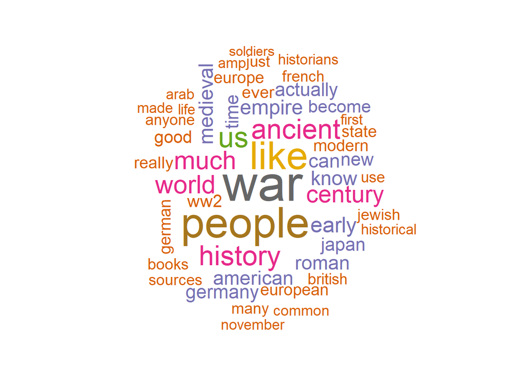

```r
# Creating a word cloud that gives the most frequent words for based on the post titles in the subreddit
library(wordcloud)

history_df %>%
  unnest_tokens(input = title, output = word) %>%
  anti_join(get_stopwords()) %>%
  count(word, sort = TRUE) %>%
  # Ensuring we exclude any words with frequencies that contain only one letter (which tend to not be useful words to have in our word cloud)
  filter(nchar(word)>1, word!="AskHistorians") %>%
  with(wordcloud(word, n, random.order = FALSE, max.words = 50, colors=pal))
```

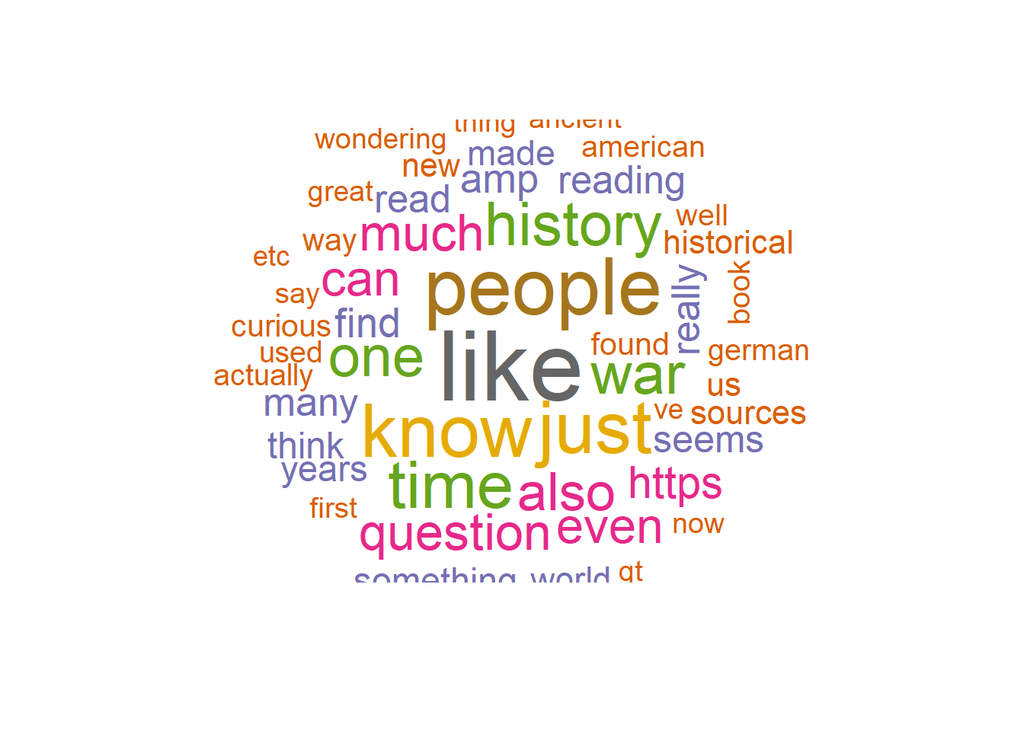

```r
# Creating a word cloud that gives the most frequent words for based on the post texts in the subreddit
library(wordcloud)

history_df %>%
  unnest_tokens(input = text, output = word) %>%
  anti_join(get_stopwords()) %>%
  count(word, sort = TRUE) %>%
  # Ensuring we exclude any words with frequencies that contain only one letter (which tend to not be useful words to have in our word cloud)
  filter(nchar(word)>1, word!="AskHistorians") %>%
  with(wordcloud(word, n, random.order = FALSE, max.words = 50, colors=pal))
```

## Conducting Sentiment Analysis

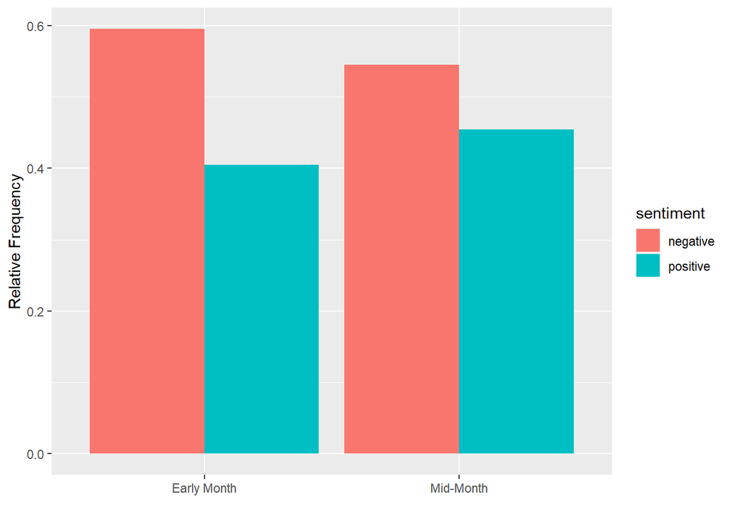

```r
# Conducting sentiment analysis comparison of early vs mid-month posts based on words in the subreddit post titles
history_df %>%
    unnest_tokens(input = title, output = word) %>%
    anti_join(get_stopwords()) %>%
    count(time_of_month, word, sort = TRUE) %>%
    group_by(time_of_month) %>%
    inner_join(get_sentiments("bing")) %>%
    filter(!is.na(sentiment)) %>%
    count(sentiment, sort = TRUE) %>%
    group_by(time_of_month) %>%
    mutate(n = n/sum(n)) %>%
    ggplot(aes(time_of_month, n, fill=sentiment))+geom_col(position = 'dodge')+
    labs(y='Relative Frequency', x ='')
```

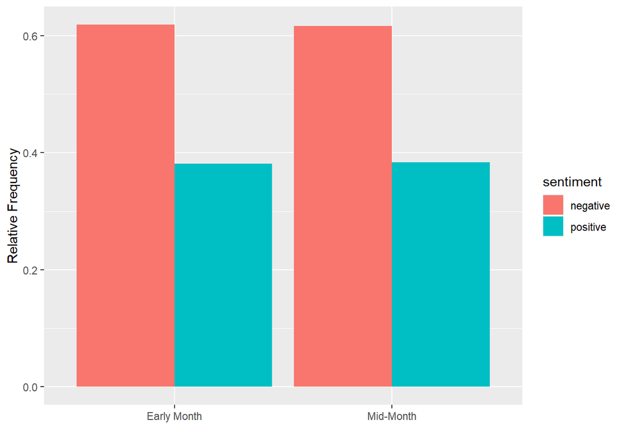

```r
# Conducting sentiment analysis comparison of early vs mid-month posts based on words in the subreddit post texts
history_df %>%
    unnest_tokens(input = text, output = word) %>%
    anti_join(get_stopwords()) %>%
    count(time_of_month, word, sort = TRUE) %>%
    group_by(time_of_month) %>%
    inner_join(get_sentiments("bing")) %>%
    filter(!is.na(sentiment)) %>%
    count(sentiment, sort = TRUE) %>%
    group_by(time_of_month) %>%
    mutate(n = n/sum(n)) %>%
    ggplot(aes(time_of_month, n, fill=sentiment))+geom_col(position = 'dodge')+
    labs(y='Relative Frequency', x ='')
```

## Modelling

```r
##########################################################################################
# Have to comment out this entire cell because I am unable to install the textrecipes package and still need to knit this section of the file
##########################################################################################

# Creating model using titles
# library(caret)
# library(themis)
# library(textrecipes)
# library(tidyverse)
#
# # Creating time of day variable that we can try to predict (will look at posts as either morning [before 12:00 pm] or afternoon [12:00 pm or later])
# history_df$time_of_day = case_when(df$time < '12:00:00' ~ "Morning",
#                          TRUE ~ "Afternoon")
#
# # Select data and set target
# history_df_model1 <- history_df %>%
#   mutate(target = time_of_day) %>%
#   select(target, title)
#
# # Convert text data to numeric variables
# b <- recipe(target~title,
#        data = history_df) %>%
#   step_tokenize(title) %>%
#   step_tokenfilter(title, max_tokens = 100) %>%
#   step_tfidf(title) %>%
#   step_normalize(all_numeric_predictors()) %>%
#   step_smote(target) %>%
#   prep()
# history_df_model1 <- juice(b)
#
#
# set.seed(12345)
# splitIndex <- createDataPartition(history_df_model1$target, p = .7,
#                                   list = FALSE)
# df_train1 <- history_df_model1[ splitIndex,]
# df_test1 <- history_df_model1[-splitIndex,]
#
# forest_ranger1 <- train(target~., data=df_train1,
#                         method = "ranger")
#
# pred1 <- predict(forest_ranger1, df_test1)
#
# cm1 <- confusionMatrix(data = pred1, reference = df_test1$target)
# cm1$overall[1]
#
# # Plotting conufsion matrix
# d1 = data.frame(pred = pred1, obs = df_test1$target)
# library(yardstick)
# d1 %>% conf_mat(pred1, obs) %>% autoplot
#
# # Creating model using text (still predicting post time of day)
#
# # Select data and set target
# history_df_model2 <- history_df %>%
#   mutate(target = time_of_day) %>%
#   select(target, text)
#
# # Convert text data to numeric variables
# c <- recipe(target~text,
#        data = history_df) %>%
#   step_tokenize(text) %>%
#   step_tokenfilter(text, max_tokens = 100) %>%
#   step_tfidf(text) %>%
#   step_normalize(all_numeric_predictors()) %>%
#   step_smote(target) %>%
#   prep()
# history_df_model2 <- juice(c)
#
#
# set.seed(12345)
# splitIndex <- createDataPartition(history_df_model2$target, p = .7,
#                                   list = FALSE)
# df_train2 <- history_df_model2[ splitIndex,]
# df_test2 <- history_df_model2[-splitIndex,]
#
# forest_ranger2 <- train(target~., data=df_train2,
#                         method = "ranger")
#
# pred2 <- predict(forest_ranger2, df_test2)
#
# cm2 <- confusionMatrix(data = pred2, reference = df_test2$target)
# cm2$overall[1]
#
# # Plotting conufsion matrix
# d2 = data.frame(pred = pred2, obs = df_test2$target)
# library(yardstick)
# d2 %>% conf_mat(pred2, obs) %>% autoplot
```